# scrattch.hicat tutorial

ZhengHu

2022-07-09

# 1 Data Selection

## 1.1 Loading libraries

首先，我们需要加载 `scattch.hicat` 和 `tasic2016data` 包，以及 `Matrix` 和 `matrixStats`，我们将使用它们进行一些计算：

```r
library(tasic2016data)
library(scrattch.hicat)
library(dendextend)
library(dplyr)
library(matrixStats)
library(Matrix)
```

## 1.2 tasic2016data overview

`tasic2016data` 包以 `tasic_2016_anno` 对象的形式提供样本注释，并以 `tasic_2016_counts` 形式提供每个基因 count 数据的矩阵。

```r
dim(tasic_2016_anno)
```

```
[1] 1809   17
```

```r
head(tasic_2016_anno)
```

|  | sample_name | mouse_line | cre_driver_1 | cre_driver_2 | cre_reporter | dissection | tdTomato | pass_qc_checks | broad_type | core_intermediate | aibs_vignette_id | primary_type_id | primary_type_label | primary_type_color | secondary_type_id | secondary_type_label | secondary_type_color |
| --- | --- | --- | --- | --- | --- | --- | --- | --- | --- | --- | --- | --- | --- | --- | --- | --- | --- |
| 1 | Calb2_tdTpositive_cell_46 | Calb2 | Calb2-IRES-Cre |  | RCL-tdT (Ai14) | upper | positive | Y | Astrocyte | core | A1631_VU | 43 | Astro Aqp4 | #C8C8C8 | 0 | none | #808080 |
| 2 | Calb2_tdTpositive_cell_48 | Calb2 | Calb2-IRES-Cre |  | RCL-tdT (Ai14) | upper | positive | Y | Astrocyte | core | A1633_VU | 43 | Astro Aqp4 | #C8C8C8 | 0 | none | #808080 |
| 3 | Calb2_tdTpositive_cell_50 | Calb2 | Calb2-IRES-Cre |  | RCL-tdT (Ai14) | lower | positive | Y | Astrocyte | core | A1635_VL | 43 | Astro Aqp4 | #C8C8C8 | 0 | none | #808080 |
| 4 | Calb2_tdTpositive_cell_53 | Calb2 | Calb2-IRES-Cre |  | RCL-tdT (Ai14) | lower | positive | Y | Astrocyte | core | A1638_VL | 43 | Astro Aqp4 | #C8C8C8 | 0 | none | #808080 |
| 5 | Calb2_tdTpositive_cell_58 | Calb2 | Calb2-IRES-Cre |  | RCL-tdT (Ai14) | lower | positive | Y | Astrocyte | core | A1643_VL | 43 | Astro Aqp4 | #C8C8C8 | 0 | none | #808080 |
| 6 | Cux2_tdTnegative_cell_2 | Cux2 | Cux2-CreERT2 |  | RCL-tdT (Ai14) | L1-L2/3 | negative | Y | Astrocyte | core | C1997n_V23 | 43 | Astro Aqp4 | #C8C8C8 | 0 | none | #808080 |

```r
dim(tasic_2016_counts)
```

```
[1] 24057  1809
```

```r
tasic_2016_counts[1:5,1:5]
```

```
              Calb2_tdTpositive_cell_1 Calb2_tdTpositive_cell_2 Calb2_tdTpositive_cell_3
0610005C13Rik                     0.00                     0.00                     0.00
0610007C21Rik                   992.00                  2287.02                   491.78
0610007L01Rik                     2.57                   177.00                     0.00
0610007N19Rik                     0.00                     0.00                     0.00
0610007P08Rik                     0.00                     0.00                     0.00
              Calb2_tdTpositive_cell_4 Calb2_tdTpositive_cell_5
0610005C13Rik                        0                        0
0610007C21Rik                     1932                     1425
0610007L01Rik                        1                        2
0610007N19Rik                        0                        0
0610007P08Rik                        0                        0
```

## 1.3 Sample selection

对于这个演示，我们将选择 CGE-derived interneurons 的一小部分进行聚类。 这为我们提供了一组 284 single-cell transcriptomic profiles， 以便后续分析步骤快速运行。

```r
select.cells <- tasic_2016_anno %>%
  filter(primary_type_label != "unclassified") %>%
  filter(grepl("Igtp|Ndnf|Vip|Sncg|Smad3", primary_type_label)) %>%
  select(sample_name) %>%
  unlist()

length(select.cells)
```

```
[1] 284
```

## 1.4 Reference setup

接下来，我们将设置 cluster annotations 以用作参考 (**ref.cl.df**)。 这些注释来自 Tasic, et al., (2016) 中的分析。

```r
ref_anno <- tasic_2016_anno %>%
  filter(sample_name %in% select.cells)

# Make a data.frame of unique cluster id, type, color, and broad type
ref.cl.df <- ref_anno %>%
  select(primary_type_id,
         primary_type_label,
         primary_type_color,
         broad_type) %>%
  unique()

#standardize cluster annoation with cluster_id, cluster_label and cluster_color. These are the required fields to visualize clusters properly.
colnames(ref.cl.df)[1:3] <- c("cluster_id", "cluster_label", "cluster_color")

# Sort by cluster_id
ref.cl.df <- arrange(ref.cl.df, cluster_id)
row.names(ref.cl.df) <- ref.cl.df$cluster_id

# Set up the ref.cl factor object
ref.cl <- setNames(factor(ref_anno$primary_type_id), ref_anno$sample_name)
```

```r
head(ref.cl.df)
```

|  | cluster_id | cluster_label | cluster_color | broad_type |
| --- | --- | --- | --- | --- |
| 1 | 1 | Smad3 | #FDDCFF | GABA-ergic Neuron |
| 2 | 2 | Ndnf Car4 | #F08080 | GABA-ergic Neuron |
| 3 | 3 | Ndnf Cxcl14 | #CD6090 | GABA-ergic Neuron |
| 4 | 4 | Vip Gpc3 | #8C6BB1 | GABA-ergic Neuron |
| 5 | 5 | Vip Chat | #F800FF | GABA-ergic Neuron |
| 6 | 6 | Vip Parm1 | #C994C7 | GABA-ergic Neuron |

```r
head(ref.cl)
```

```
Gad2_tdTpositive_cell_18 Gad2_tdTpositive_cell_25 Gad2_tdTpositive_cell_26 Gad2_tdTpositive_cell_40
                       1                        1                        1                        1
Gad2_tdTpositive_cell_48 Gad2_tdTpositive_cell_49
                       1                        1
Levels: 1 2 3 4 5 6 7 8 9 23
```

## 1.5 Data normalization

为了归一化数据，我们将执行两个步骤： 首先，使用 `cpm()` 函数将 counts 转换为 counts per million reads (CPM)。 然后，使用 `log2()` 函数对结果进行对数转换。

```r
tasic_2016_cpm <- cpm(tasic_2016_counts[,select.cells])
norm.dat <- log2(tasic_2016_cpm + 1)
```

如果您有一个非常大的矩阵，我们建议您使用 `Matrix` 包将其转换为稀疏矩阵以节省内存。 虽然这里没有必要，但我们将这样做来演示这些矩阵的使用。

```r
norm.dat <- Matrix(norm.dat, sparse = TRUE)
```

# 2 Setting Parameters

## 2.1 Parameter Descriptions

这种迭代聚类算法产生的最终聚类数量很大程度上取决于用户指定的所需细胞类型分辨率。 细胞类型分辨率由 pair of clusters 之间的差异表达 (DE) 标准定义。 用户可以提前指定这些标准，以便通过使用 `de_param()` 函数在 hicat 函数中重新使用。

我们使用 `limma` 计算 DE genes 的统计意义，其中两个关键参数指定如下：  
**padj.th**: adjusted p value threshold for DE genes.  
**lfc.th**: log2 fold change threshold for DE genes.

我们还要求 DE genes 具有相对 binary (on/off) 的表达模式，由以下参数指定：  
**low.th**: 用于确定是否在给定细胞中检测到基因的最小值。 此阈值适用于 log2-transformed, normalized data。默认值为 1。 如有必要，用户可以为不同的基因指定不同的阈值。 对于每一对 clusters (one as foreground, and the other as background)，我们定义了 q1 和 q2 作为分别在 foreground 和 background cluster 中表达大于 low.th 的细胞的比例。  
**q1.th**：对于上调基因，q1 应该大于 foreground set 中的 q1.th。  
**q2.th**：对于上调基因，q2 应该小于background set 中的 q2.th。  
**q.diff.th**：差异，定义为 abs(q1 - q2)/max(q1, q2) 应大于 q.diff.th。  
**默认值**：**q1.th** = 0.5, **q2.th** = NULL, **q.diff.th** = 0.7.

用户也可以通过将它们全部设置为 NULL 来忽略这些参数。  
对于高深度数据集，例如使用 SMARTerV4 或 Smart-Seq2 生成的数据集，我们建议从 **q1.th** = 0.5 开始。  
对于低深度数据集，例如使用 Dropseq 或 10X Genomics 生成的数据集，我们建议从 **q1.th** = 0.3 开始， 因为这些数据集中每个细胞的基因检测通常较低。  
当关注离散细胞类型时，将 **q.diff.th** 设置为更接近 1。  
如果对基于基因表达的分级或组合差异的细胞类型进行拆分感兴趣，请将 **q.diff.th** 调整为更接近 0。

为了根据 DE genes 确定两个 clusters 是否可分离，我们将 **de.score** 定义为所有 DE genes 的 -log10(adjusted Pvalue) 的总和。每个基因对总和的贡献最多为 20。所有 clusters 的 pairwise de.score 都应该大于 **de.score.th**。  
对于小型数据集（#cells < 1000），我们建议 **de.score.th** = 40。  
对于大型数据集（#cells > 10000），我们建议 **de.score.th** = 150。

**min.cells** 是每个 cluster 中允许的最小细胞数目。  
**min.genes** 是分离 cluster 所需的差异表达基因的最小数量。  
低于 min.cells 和 min.genes 的 Clusters 将与低维空间中最近的 Clusters 合并。

## 2.2 Setting clustering parameters

```r
de.param <- de_param(padj.th     = 0.05,
                     lfc.th      = 1,
                     low.th      = 1,
                     q1.th       = 0.3,
                     q2.th       = NULL,
                     q.diff.th   = 0.7,
                     de.score.th = 40,
                     min.cells   = 10,
                     min.genes = 5)
```

# 3 Dimension Filtering

可以使用我们称为 **rm.eigen** 的矩阵来指定在聚类过程中应该屏蔽的技术变化。 如果存在批次效应，您可以使用批次特异性基因的第一主成分作为 **rm.eigen** 中的一列。

QC-related factors，例如测序深度、基因检测限制和比对到转录组的 reads 分数也往往与 基因表达的系统技术变异相关。

您可以直接使用这些 QC-related variables 的适当转换，或使用与这些 QC factors 相关 的基因的第一主成分。后一种方法往往更适用于真实数据集。当指定 **rm.eigen** 时，聚 类期间任何与 **rm.eigen** 的任何列具有大于 **rm.th** 的相关性的降维向量在聚类期间 将被忽略。

我们建议用户首先通过运行 clustering pipeline 而不设置 **rm.eigen** 来探索他们的数据。 如果任何批次特定或 QC-driven clusters 出现问题，用户可以创建 **rm.eigen** 如下所示， 然后重新运行 pipeline。

```r
gene.counts <- colSums(norm.dat > 0)
rm.eigen <- matrix(log2(gene.counts), ncol = 1)
row.names(rm.eigen) <- names(gene.counts)
colnames(rm.eigen) <- "log2GeneCounts"
```

# 4 Clustering

## 4.1 Choosing a dimensionality reduction method

`scrattch.hicat` 可以使用 **WGCNA** 或 **PCA** 进行聚类以进行降维。 **WGCNA** 模式有利于检测稀有 clusters 并提供更清晰的 cluster 边界，而 **PCA** 更适合大型数据集，更有效地捕获组合标记表达模式，并且对低深度数据集更敏感。

我们建议对于较小的、高深度数据集 (< 4,000 samples; > 5,000 genes detecter per sample) 使用 **WGCNA**，对于大型或低覆盖数据集 (> 4,000 samples or < 5,000 genes detected per sample) 使用 **PCA**。

另一个考虑因素是 **WGCNA** 比 **PCA** 慢得多。请注意，虽然整个 clustering pipeline 可以很好地随着细胞的数量而扩展，但运行时间在很大程度上取决于细胞类型的复杂性。 也就是说，如果您的细胞非常多样化并继续分裂，则需要进一步的迭代才能达到终止标准。

## 4.2 Coarse-level clustering

```r
strict.param <- de_param(de.score.th = 500)

onestep.result <- onestep_clust(norm.dat,
                                select.cells = select.cells,
                                dim.method = "pca",
                                de.param = strict.param,
                                rm.eigen = rm.eigen)
```

我们可以使用 `display_cl()` 函数绘制 DE Genes 的热图：

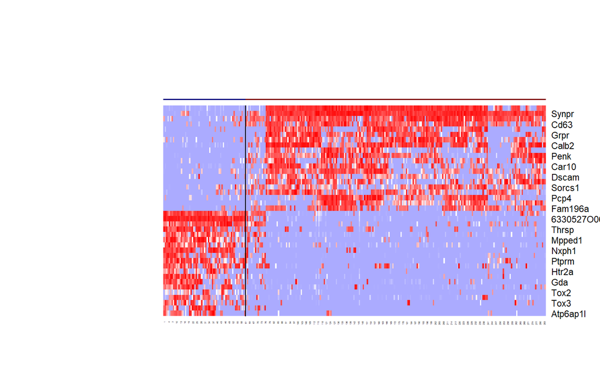

```r
display.result <- display_cl(onestep.result$cl, norm.dat, plot = TRUE, de.param = de.param)
```

我们可以在这里看到，样本根据许多差异表达的基因分成了两个大的亚类。

## 4.3 Iteration for more detail

接下来，我们将使用我们之前定义的更宽松的阈值 (**de.param**) 来寻找这些粗略 clusters 的更精细分割。这是通过运行 `iter_clust()` 函数来完成的。

`iter_clust()` 将执行迭代聚类，直到所有划分的 clusters 按照 **de.param** 中设置的标准的合并。

我们可以通过 `result` 参数向 `iter_clust()` 函数提供之前的单轮结果 (**onestep.result**)，从而避免从头开始：

```r
iter.result <- iter_clust(norm.dat,
                          select.cells = select.cells,
                          dim.method = "pca",
                          de.param = de.param,
                          rm.eigen = rm.eigen,
                          result = onestep.result)
```

```
[1] ".1"
[1] ".2"
[1] ".2.1"
[1] ".2.2"
[1] ".2.3"
[1] ".2.4"
[1] ".2.5"
```

我们再次查看热图

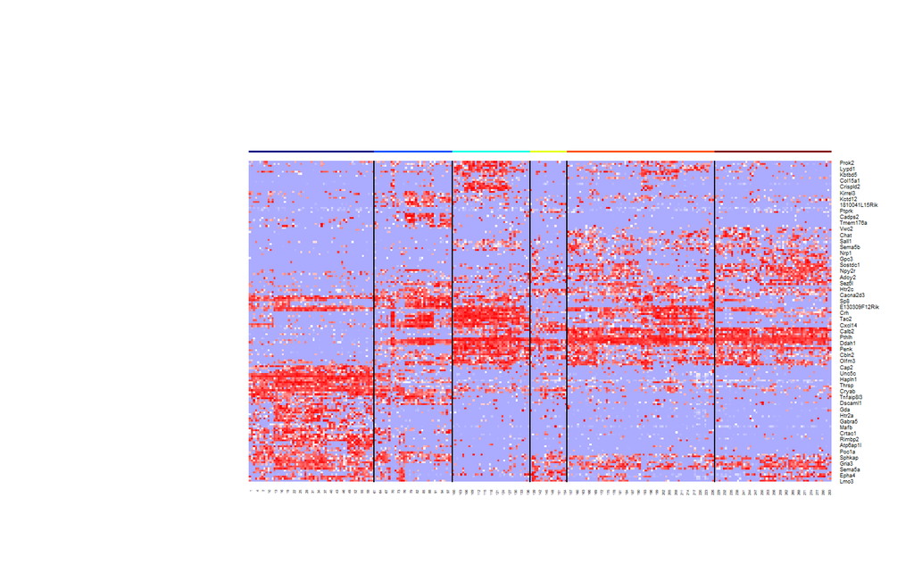

```r
display.result <- display_cl(iter.result$cl, norm.dat, plot = TRUE, de.param = de.param)
```

## 4.4 Experimenting with parameters

要查看 `de_param()` 设置的各种参数如何影响聚类结果，请按照下面尝试使用一些不同的 设置运行 `onestep_clust()` 函数。您还可以尝试将 **WGCNA** 和 **PCA** 作为 dim.method 参数进行比较。

```r
dim.method <- "WGCNA"

explore.param <- de_param(padj.th     = 0.05,
                          lfc.th      = 1,
                          low.th      = 1,
                          q1.th       = 0.5,
                          q2.th       = NULL,
                          q.diff.th   = 0.7,
                          de.score.th = 40)

explore.result <- onestep_clust(norm.dat,
                                select.cells = select.cells,
                                dim.method = dim.method,
                                de.param = explore.param,
                                rm.eigen = rm.eigen)
```

```
 ..done.
```

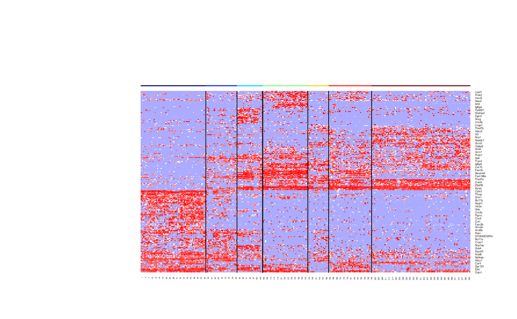

```r
display.result <- display_cl(explore.result$cl,
                             norm.dat,
                             plot = TRUE,
                             de.param = explore.param)
```

# 5 Merging and comparison

## 5.1 Merging clusters

在 `iter_clust()` 执行的迭代聚类过程中，该函数检查任何迭代的聚类是否可以被 DEG 分离。 但是，来自不同迭代的 clusters 最终可能非常相似。因此，最终有必要检查所有 clusters 是否可以通过 DEG 分离。

Clusters 按照最近邻的 pairs of clusters 定义的顺序合并，这些 clusters 在由 **rd.dat** 定义的降维空间中计算。

在这里，我们使用由 `iter_clust()` 生成的一组 markers 来定义降维。出于演示的目的， 我们将增加 **de.param** 设置的严格性以合并相似的 clusters。

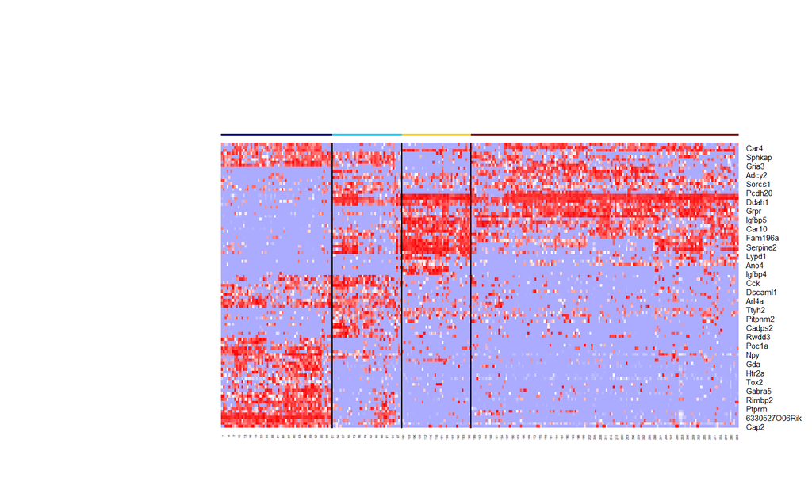

```r
rd.dat <- t(norm.dat[iter.result$markers, select.cells])

merge.param <- de_param(de.score.th = 70) # The original value was 40.

merge.result <- merge_cl(norm.dat,
                         cl = iter.result$cl,
                         rd.dat = rd.dat,
                         de.param = merge.param)

display.result <- display_cl(merge.result$cl,
                             norm.dat,
                             plot = TRUE,
                             de.param = merge.param)
```

让我们使用 `compare_annotate()` 函数比较合并前和合并后的 clusters，看看哪些合并了：

```r
# Set up the cl and cl.df objects for use with compare_annotate()
iter.cl <- setNames(as.factor(iter.result$cl), select.cells)
iter.cl.df <- data.frame(cluster_id = unique(iter.cl),
                            cluster_label = paste0("Pre-merge_cl_",unique(iter.cl)),
                            cluster_color = rainbow(length(unique(iter.cl))))
rownames(iter.cl.df) <- iter.cl.df$cluster_id

compare.result <- compare_annotate(merge.result$cl, iter.cl, iter.cl.df)
```

```
[1] 6
```

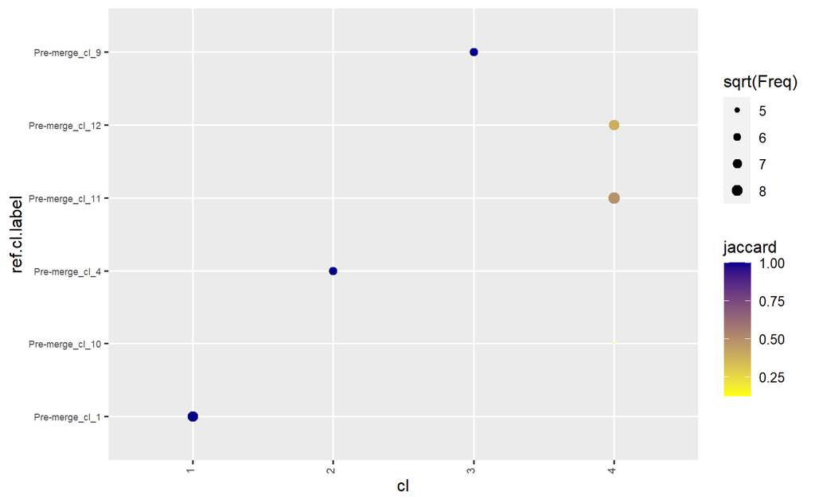

```r
compare.result$g
```

## 5.2 Comparison to reference clusters

在这个演示中，我们之前从 Tasic, et al., 2016 中获得了 cluster 标签。要查看这些 cluster 标签与 `scrattch.hicat` 生成的 cluster 标签如何匹配，我们可以根据 reference cluster annotation 来比较和注释 cluster。

```r
# Generate comparison
compare.result <- compare_annotate(iter.result$cl, ref.cl, ref.cl.df)
```

```
[1] 10
```

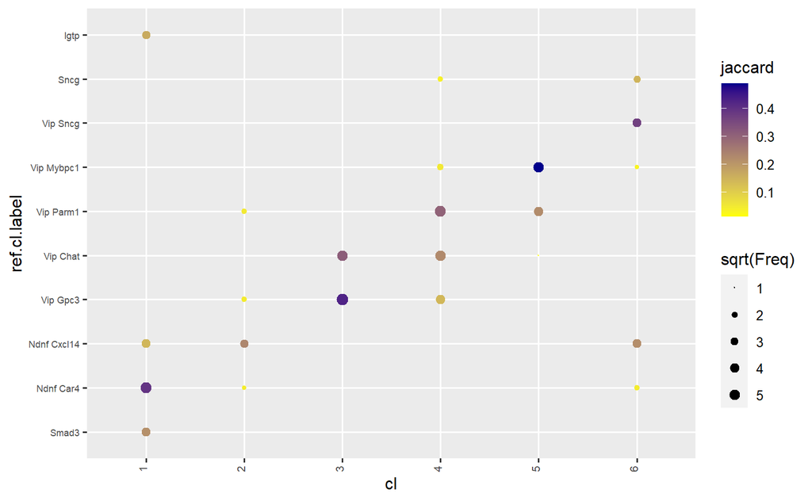

```r
# Output the plot
compare.result$g
```

```r
# Get cl factors and data.frame
cl <- compare.result$cl
cl.df <- compare.result$cl.df
```

现在让我们计算每对 clusters 之间的 DE genes。为了生成这个热图，我们使用了top 20 DE genes。如果您有许多 clusters，则热图可能太大而无法显示，这可能需要较低的 n.markers 参数设置。

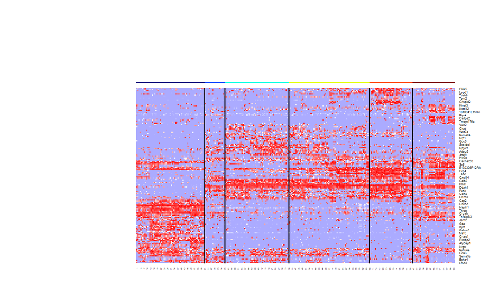

```r
display.result <- display_cl(cl,
                             norm.dat,
                             plot=TRUE,
                             de.param = de.param,
                             n.markers = 20)
```

```r
de.genes <- display.result$de.genes
```

此时，我们可以检查热图以手动检查 clusters 中是否存在奇怪的分组、doublets 或异常值。